# AR_us_retail

### Auto Regressive (AR) models

The previous example demonstrated how to fit Exponential Smoothing family forecasting methods. These methods build off the simple MEAN and Naive forecastors. Another class of forecasting methods are known as Auto Regressive or AR models. The terminology and nomenclature of such models seem like a completely different strategy and procedure. AR models include **no new** concepts! Those concepts are just **packaged differently** and often described using other vocabularly. This notebook demonstrates how AR models are just Linear Models and use the **exact same** assumptions of the "regular" Linear Model we have discussed multiple times. This notebook shows that functions that specialize in fitting AR models manage the tedious data manipulation tasks required to create the features for such models. This notebook concludes by showing how to use Information Criterion metrics to identify the BEST way of formulating AR models.

## Import Modules

```python
import numpy as np
import pandas as pd
import matplotlib.pyplot as plt

import seaborn as sns
```

```python
import statsmodels.api as sm
```

## Read data

Use the monthly US Retail Employment data set introduced last week.

```python
us_retail_df = pd.read_csv('../week_10/us_retail_employment.csv')
```

## Prepare data

The data are prepared for time series analysis using the same procedure demonstrated previously.

```python
us_retail_df['date_dt'] = pd.to_datetime( us_retail_df.loc[:, ['Year', 'Month', 'Day']] )

retail_series = us_retail_df.Employed.copy()

retail_series.index = us_retail_df.date_dt

ready_series = retail_series.copy().resample('MS').mean()
```

As a check the prepared time series is visualized below.

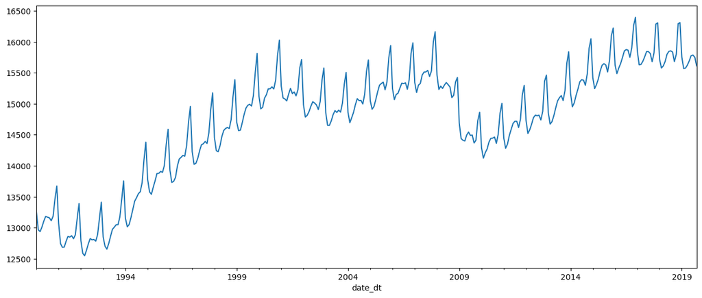

```python
ready_series.plot( figsize=(15, 6) )

plt.show()
```

## Split data

We will use a dedicated training set consisting of all data through 2016. The measurements for 2017 through 2019 will be reserved as a hold-out test set.

```python
train_series = ready_series.loc[ ready_series.index < '2017-01-01' ].copy()

test_series = ready_series.loc[ ready_series.index >= '2017-01-01' ].copy()
```

The training and test series are visualized below.

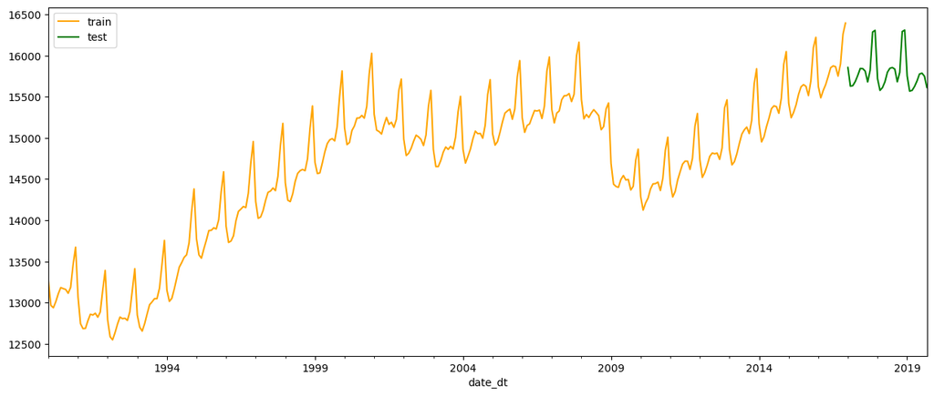

```python
fig, ax = plt.subplots(figsize=(15, 6))

train_series.plot( ax = ax, label = 'train', color='orange' )

test_series.plot( ax = ax, label = 'test', color = 'green' )

ax.legend()

plt.show()
```

## AR Models

This notebook will not demonstrate the simple forecasting methods. Instead, this notebook jumps straight to the AutoRegressive (AR) models. Please see the presentation provided last week for more details on AR models. Please see, the Rob Hyndman [Forecasting: Principles and Practice AR section](https://otexts.com/fpp3/AR.html) for additional details. Specific `statsmodels` AR discussion and examples are available in the [statsmodels AR documentation](https://www.statsmodels.org/stable/examples/notebooks/generated/autoregressions.html).

AR models are just linear models, **but** they use a very specific set of **features**. The features are **past observations** of the output. The model therefore corresponds to predicting the future **GIVEN** the past. This is the **same** goal as the Exponential smoothing family discussed previously. The difference is that **we** the modeler the specify the exact **past** observations to include.

The features derived from past observations are referred to as **lags**. A lag is the prior observation. The motivations for using the lags stems from the **lag plot** discussed last week. For example, we may wish to relate lag=1 observations. As shown below, knowing the current observation, `y(t)`, tells us alot about the **next** observation, `y(t+1)`.

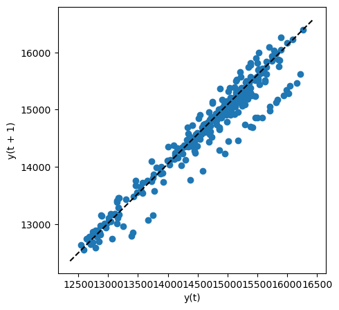

```python
fig, ax = plt.subplots(figsize=(5, 5))

pd.plotting.lag_plot( train_series, lag=1, ax=ax )

plt.plot( ax.get_xlim(), ax.get_ylim(), 'k--' )

plt.show()
```

Likewise, knowing the current observation, `y(t)`, also tells us a lot about an observation two **steps** ahead. This is shown by the lag=2 plot.

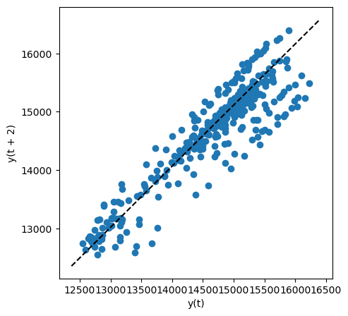

```python
fig, ax = plt.subplots(figsize=(5, 5))

pd.plotting.lag_plot( train_series, lag=2, ax=ax )

plt.plot( ax.get_xlim(), ax.get_ylim(), 'k--' )

plt.show()
```

The autocorrelation plot summarizes just how many lags are relevant.

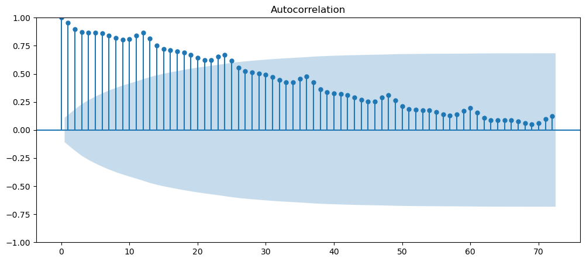

```python
fig, ax = plt.subplots(figsize=(12, 5))

sm.graphics.tsa.plot_acf( train_series.values.squeeze(), lags=72, ax=ax )

plt.show()
```

Highly correlated time series will have autocorrelation plots that seem to suggest all lags are important. The **partial** autocorrelation can help in such situations because it represents the relationship with a lag while controlling for the prior lag. The partial autocorrelation therefore represents a more **direct** relationship between an observation and a lag. Please see this [Machine Learning Mastery post](https://machinelearningmastery.com/gentle-introduction-autocorrelation-partial-autocorrelation/) if you would like to learn more about PACF.

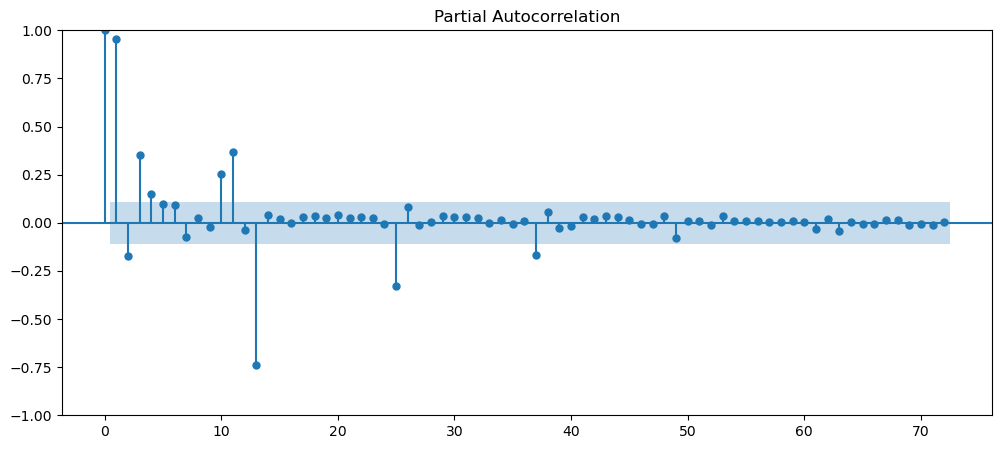

```python
fig, ax = plt.subplots( figsize = (12, 5) )

sm.graphics.tsa.plot_pacf( train_series.values.squeeze(), lags=72, ax = ax)

plt.show()
```

How can **lags** be included as features in the model? Specialized AR model functions exist to manage this for us. The `statsmodels` module `AutoReg()` function is imported below.

```python
from statsmodels.tsa.ar_model import AutoReg
```

Let's begin with an AR model with 1 lag. The `old_names` argument is a legacy `statsmodels` argument. You can safely set it to `False`.

```python
train_ar_01_model_fit = AutoReg( train_series, 1, old_names=False).fit()
```

Look closely at the printed summary below. The AR-1 model consists of 2 coefficients. The `const` and `Employed.L1` coefficients. What do you think those coefficients represent?

```python
print( train_ar_01_model_fit.summary() )
```

```
                            AutoReg Model Results
==============================================================================
Dep. Variable:               Employed   No. Observations:                  324
Model:                     AutoReg(1)   Log Likelihood               -2224.624
Method:               Conditional MLE   S.D. of innovations            237.090
Date:                Tue, 14 Mar 2023   AIC                           4455.247
Time:                        21:48:15   BIC                           4466.580
Sample:                    02-01-1990   HQIC                          4459.771
                         - 12-01-2016
===============================================================================
                  coef    std err          z      P>|z|      [0.025      0.975]
-------------------------------------------------------------------------------
const         493.5964    215.593      2.289      0.022      71.042     916.151
Employed.L1     0.9669      0.015     65.684      0.000       0.938       0.996
                                    Roots
=============================================================================
                  Real          Imaginary           Modulus         Frequency
-----------------------------------------------------------------------------
AR.1            1.0342           +0.0000j            1.0342            0.0000
-----------------------------------------------------------------------------
```

### AR models and "regular" linear models

Those two coefficients are the intercept and slope of a "regular" linear model with a single input! To highlight that, `train_ar_01_model_fit` has a `.params` attribute just like the `smf.ols()` fit objects!

```python
train_ar_01_model_fit.params
```

```
const          493.596450
Employed.L1      0.966899
dtype: float64
```

We could "manually" fit the AR model by manually organizing the lags! You do **not** to typically do this, but it is illustrative to see how this works since it highlights AR models are just "regular" linear models! The cell below prints the training series to the screen. The first observation corresponds to January 1990 and has a value of 13255.8. The last observation corresponds to December 2016 and has a value of 16394.3.

```python
train_series
```

```
date_dt
1990-01-01    13255.8
1990-02-01    12966.3
1990-03-01    12938.2
1990-04-01    13012.3
1990-05-01    13108.3
               ...
2016-08-01    15864.6
2016-09-01    15750.3
2016-10-01    15899.5
2016-11-01    16260.2
2016-12-01    16394.3
Freq: MS, Name: Employed, Length: 324, dtype: float64
```

The Pandas `.shift()` method will "shift" the Series "backwards" a defined number of periods. These *shifts* correspond to the **lagged** values. The cell below shows the 1 lag values. January 1990 has a "shifted" or **lagged** value of NaN because the data starts in January 1990. The previous value in December 1989 is **missing** and so we do **not** know the lagged value for the initial observation! However, the last **lagged** value is not missing. The last lagged value is 16260.2. This is the value associated with November 2016. Thus, the 1 Season (month) lag in December 2016 is the value 1 Season (month) prior in November 2016!

```python
train_series.shift(periods=1)
```

```
date_dt
1990-01-01        NaN
1990-02-01    13255.8
1990-03-01    12966.3
1990-04-01    12938.2
1990-05-01    13012.3
               ...
2016-08-01    15874.4
2016-09-01    15864.6
2016-10-01    15750.3
2016-11-01    15899.5
2016-12-01    16260.2
Freq: MS, Name: Employed, Length: 324, dtype: float64
```

Let's organize the lagged values into a DataFrame. The names are set to be consistent with the `AutoReg()` function naming conventions.

```python
df_1_lags = pd.DataFrame({'date_dt': train_series.index,
                          'Employed': train_series.values.copy(),
                          'Employed_L1': train_series.shift(periods=1).values.copy()})
```

We now clearly see that the **lagged** value in Ferurary 1990 is the value from January 1990!

```python
df_1_lags
```

|  | date_dt | Employed | Employed_L1 |
| --- | --- | --- | --- |
| 0 | 1990-01-01 | 13255.8 | NaN |
| 1 | 1990-02-01 | 12966.3 | 13255.8 |
| 2 | 1990-03-01 | 12938.2 | 12966.3 |
| 3 | 1990-04-01 | 13012.3 | 12938.2 |
| 4 | 1990-05-01 | 13108.3 | 13012.3 |
| ... | ... | ... | ... |
| 319 | 2016-08-01 | 15864.6 | 15874.4 |
| 320 | 2016-09-01 | 15750.3 | 15864.6 |
| 321 | 2016-10-01 | 15899.5 | 15750.3 |
| 322 | 2016-11-01 | 16260.2 | 15899.5 |
| 323 | 2016-12-01 | 16394.3 | 16260.2 |

324 rows × 3 columns

Linear models cannot work with missing values. Drop all missing values to create the *complete cases*.

```python
df_1_lags_ready = df_1_lags.dropna().copy()
```

```python
df_1_lags_ready
```

|  | date_dt | Employed | Employed_L1 |
| --- | --- | --- | --- |
| 1 | 1990-02-01 | 12966.3 | 13255.8 |
| 2 | 1990-03-01 | 12938.2 | 12966.3 |
| 3 | 1990-04-01 | 13012.3 | 12938.2 |
| 4 | 1990-05-01 | 13108.3 | 13012.3 |
| 5 | 1990-06-01 | 13182.8 | 13108.3 |
| ... | ... | ... | ... |
| 319 | 2016-08-01 | 15864.6 | 15874.4 |
| 320 | 2016-09-01 | 15750.3 | 15864.6 |
| 321 | 2016-10-01 | 15899.5 | 15750.3 |
| 322 | 2016-11-01 | 16260.2 | 15899.5 |
| 323 | 2016-12-01 | 16394.3 | 16260.2 |

323 rows × 3 columns

Let's bring in the `statsmodels` formula interface and fit the linear regression model!

```python
import statsmodels.formula.api as smf
```

The output is the `Employed` value and the input feature is the `Employed_L1` column. Or, the input feature is the **lagged** value from the previous Season (month).

```python
my_ar_1_mod = smf.ols(formula='Employed ~ Employed_L1', data = df_1_lags_ready).fit()
```

```python
print( my_ar_1_mod.summary() )
```

```
                            OLS Regression Results
==============================================================================
Dep. Variable:               Employed   R-squared:                       0.930
Model:                            OLS   Adj. R-squared:                  0.930
Method:                 Least Squares   F-statistic:                     4288.
Date:                Tue, 14 Mar 2023   Prob (F-statistic):          9.01e-188
Time:                        22:01:39   Log-Likelihood:                -2224.6
No. Observations:                 323   AIC:                             4453.
Df Residuals:                     321   BIC:                             4461.
Df Model:                           1
Covariance Type:            nonrobust
===============================================================================
                  coef    std err          t      P>|t|      [0.025      0.975]
-------------------------------------------------------------------------------
Intercept     493.5964    216.264      2.282      0.023      68.123     919.069
Employed_L1     0.9669      0.015     65.480      0.000       0.938       0.996
==============================================================================
Omnibus:                       78.161   Durbin-Watson:                   1.613
Prob(Omnibus):                  0.000   Jarque-Bera (JB):              150.680
Skew:                          -1.282   Prob(JB):                     1.91e-33
Kurtosis:                       5.149   Cond. No.                     2.39e+05
==============================================================================

Notes:
[1] Standard Errors assume that the covariance matrix of the errors is correctly specified.
[2] The condition number is large, 2.39e+05. This might indicate that there are
strong multicollinearity or other numerical problems.
```

The regression coefficient estimates from our manual linear model are the same values we saw previously from the AR-1 model!

```python
my_ar_1_mod.params
```

```
Intercept      493.596450
Employed_L1      0.966899
dtype: float64
```

```python
train_ar_01_model_fit.params
```

```
const          493.596450
Employed.L1      0.966899
dtype: float64
```

More complex AR models represent including more **lags** as features in the model. The model must therefore estimate additional coefficients (slopes) that multiply these additional **lagged** observations. Let's manually create the linear model with the lag=1 and lag=2 features.

```python
df_2_lags = pd.DataFrame({'date_dt': train_series.index,
                          'Employed': train_series.values.copy(),
                          'Employed_L1': train_series.shift(periods=1).values.copy(),
                          'Employed_L2': train_series.shift(periods=2).values.copy()})
```

As shown below, there `Employed_L2` column has 2 MISSING rows! December 1989 is the 1-lag feature for January 1990 **and** the 2-lag feature for February 1990. Thus, we do **not** know **all** features for **more** observations as more lags are included in the model.

```python
df_2_lags
```

|  | date_dt | Employed | Employed_L1 | Employed_L2 |
| --- | --- | --- | --- | --- |
| 0 | 1990-01-01 | 13255.8 | NaN | NaN |
| 1 | 1990-02-01 | 12966.3 | 13255.8 | NaN |
| 2 | 1990-03-01 | 12938.2 | 12966.3 | 13255.8 |
| 3 | 1990-04-01 | 13012.3 | 12938.2 | 12966.3 |
| 4 | 1990-05-01 | 13108.3 | 13012.3 | 12938.2 |
| ... | ... | ... | ... | ... |
| 319 | 2016-08-01 | 15864.6 | 15874.4 | 15851.8 |
| 320 | 2016-09-01 | 15750.3 | 15864.6 | 15874.4 |
| 321 | 2016-10-01 | 15899.5 | 15750.3 | 15864.6 |
| 322 | 2016-11-01 | 16260.2 | 15899.5 | 15750.3 |
| 323 | 2016-12-01 | 16394.3 | 16260.2 | 15899.5 |

324 rows × 4 columns

The complete cases for the 2-lag model are created below.

```python
df_2_lags_ready = df_2_lags.dropna().copy()
```

The Linear Model with 1-lag and 2-lag features is fit below. The formula consists of linear additive features!

```python
my_ar_2_mod = smf.ols(formula='Employed ~ Employed_L1 + Employed_L2', data = df_2_lags_ready).fit()
```

The coefficients for the Linear Model with the 1-lag and 2-lag features are:

```python
my_ar_2_mod.params
```

```
Intercept      628.182045
Employed_L1      1.156285
Employed_L2     -0.198644
dtype: float64
```

How do these coefficients compare to using a specialized AR modeling function? Let's find out!

```python
train_ar_02_model_fit = AutoReg( train_series, 2, old_names=False).fit()
```

The AR coefficients for the 2-lag case are **the same** as those estimated manually by the Linear Model!

```python
train_ar_02_model_fit.params
```

```
const          628.182045
Employed.L1      1.156285
Employed.L2     -0.198644
dtype: float64
```

**Why does this matter?**

AutoRegressive (AR) models at first might seem like a brand new class of model. The terminology is challenging but as you have just seen we can manually create AR models by fittin the models with `smf.ols()` **if** the appropriate lagged features have been included. This means:

- AR models have Gaussian Likelihoods just like Linear Models!
- AR models have the SAME assumptions about the residuals (errors) as Linear Models!
- AR models are fit by MAXIMIZING the Gaussian Likelihood which is equivalent to minimizing the SSE.
- AR models use lagged observations as inputs and assume Linear Additive Features from those inputs.
- Adding more lags increases the number of features, which increases the number of coefficients, which increases complexity.
- Adding more lags increases the number of MISSING entries, which decreases the number of complete training cases.

You do not need to manually generate the lags when working with AR models. Instead, you can use the `AutoReg()` function to manage the process for you. This example was provided to help make it more clear just what the AR model is doing.

The similarities between AR models and "regular" Linear Models are reinforced by the fact that `statsmodels` includes a specialized diagnostic plot for AR models. This diagnostic plot focuses on the behavior of the residuals. If the assumptions of the Linear Model are satisfied, then the residuals will not have a clear trend, the residuals will not be correlated, and the residuals will have a Gaussian distribution. Do you think the assumptions of the linear model are satisfied for the lag-1 AR model based on the figure below?

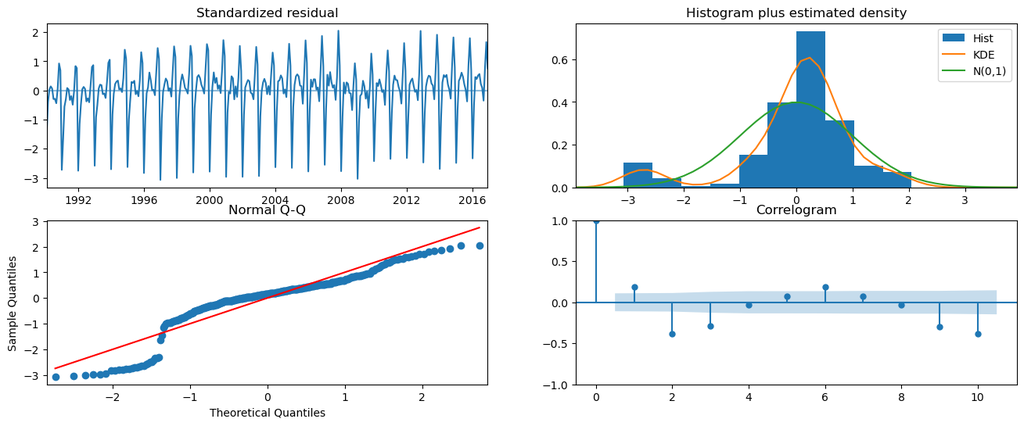

```python
train_ar_01_model_fit.plot_diagnostics(figsize=(16,6))

plt.show()
```

What about for the AR model with 2-lags?

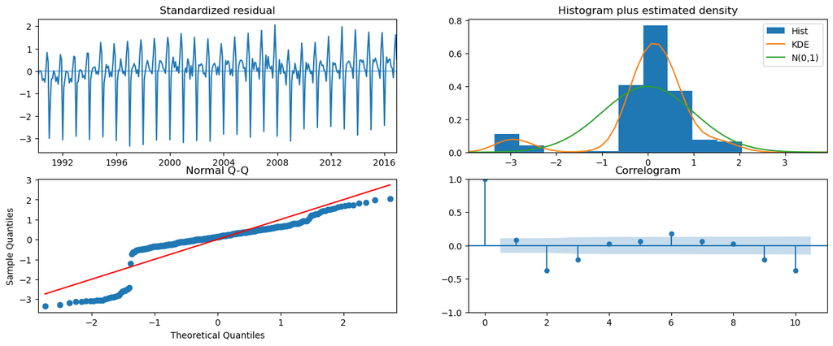

```python
train_ar_02_model_fit.plot_diagnostics(figsize=(16,6))

plt.show()
```

### Forecast visualizations

If we are just interested in the forecasted **AVERAGE OUTPUT**, we can make forecasts with AR models just like the forecasts from SES and Holt-Winters. The `.forecast()` method requires the number of forecast steps or **horizons**. One season ahead is accomplished by forecasting 1 horizon.

```python
train_ar_01_model_fit.forecast(1)
```

```
2017-01-01    16345.228348
Freq: MS, dtype: float64
```

Forecasting the entire hold out TEST SET is therefore accomplished by specifying the number of forecasting horizons to equal the `.size` of the test set.

```python
train_ar_01_model_fit.forecast( test_series.size )
```

```
2017-01-01    16345.228348
2017-02-01    16297.781019
2017-03-01    16251.904244
2017-04-01    16207.546037
2017-05-01    16164.656133
2017-06-01    16123.185928
2017-07-01    16083.088430
2017-08-01    16044.318200
2017-09-01    16006.831303
2017-10-01    15970.585262
2017-11-01    15935.539002
2017-12-01    15901.652808
2018-01-01    15868.888283
2018-02-01    15837.208296
2018-03-01    15806.576950
2018-04-01    15776.959533
2018-05-01    15748.322482
2018-06-01    15720.633347
2018-07-01    15693.860751
2018-08-01    15667.974355
2018-09-01    15642.944825
2018-10-01    15618.743798
2018-11-01    15595.343850
2018-12-01    15572.718465
2019-01-01    15550.842002
2019-02-01    15529.689673
2019-03-01    15509.237508
2019-04-01    15489.462330
2019-05-01    15470.341731
2019-06-01    15451.854043
2019-07-01    15433.978317
2019-08-01    15416.694295
2019-09-01    15399.982393
Freq: MS, dtype: float64
```

The 1-lag AR model forecast is visualized below. The training set "fits" are included by accessing the `.fittedvalues` attribute. The 1-lag AR model does not capture the seasonal variation. The forecast starts out similar to the Naive method but the forecast is **not** constant. The forecast **regresses** to the mean in the long run!

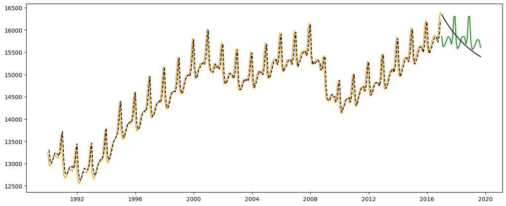

```python
fig, ax = plt.subplots( figsize=(15, 6) )

ax.plot( train_series, color='orange', label='train' )

ax.plot( test_series, color = 'green', label ='test' )

ax.plot( train_ar_01_model_fit.fittedvalues, color='black', linestyle='--', label='fits' )

ax.plot( train_ar_01_model_fit.forecast(test_series.size), color='black', label='forecast' )

plt.show()
```

Since AR models are just Linear Models, we can also extract and visualize their Prediction Intervals! The syntax for doing so is not as straightforward as the `.forecast()` method. We cannot specify the number of horizons. Instead, we must specify how to start the forecast and end the forecast with the `.get_prediction()` method. The documentation for the `.get_prediction()` is provided below for reference. The `.get_prediction()` method returns an object which allows the AVERAGE OUTPUT and Prediction Intervals to be calculated.

```python
help( train_ar_01_model_fit.get_prediction )
```

```
Help on method get_prediction in module statsmodels.tsa.ar_model:

get_prediction(start=None, end=None, dynamic=False, exog=None, exog_oos=None) method of statsmodels.tsa.ar_model.AutoRegResults instance
    Predictions and prediction intervals

    Parameters
    ----------
    start : int, str, or datetime, optional
        Zero-indexed observation number at which to start forecasting,
        i.e., the first forecast is start. Can also be a date string to
        parse or a datetime type. Default is the the zeroth observation.
    end : int, str, or datetime, optional
        Zero-indexed observation number at which to end forecasting, i.e.,
        the last forecast is end. Can also be a date string to
        parse or a datetime type. However, if the dates index does not
        have a fixed frequency, end must be an integer index if you
        want out-of-sample prediction. Default is the last observation in
        the sample. Unlike standard python slices, end is inclusive so
        that all the predictions [start, start+1, ..., end-1, end] are
        returned.
    dynamic : {bool, int, str, datetime, Timestamp}, optional
        Integer offset relative to `start` at which to begin dynamic
        prediction. Prior to this observation, true endogenous values
        will be used for prediction; starting with this observation and
        continuing through the end of prediction, forecasted endogenous
        values will be used instead. Datetime-like objects are not
        interpreted as offsets. They are instead used to find the index
        location of `dynamic` which is then used to to compute the offset.
    exog : array_like
        A replacement exogenous array.  Must have the same shape as the
        exogenous data array used when the model was created.
    exog_oos : array_like
        An array containing out-of-sample values of the exogenous variable.
        Must has the same number of columns as the exog used when the
        model was created, and at least as many rows as the number of
        out-of-sample forecasts.

    Returns
    -------
    PredictionResults
        Prediction results with mean and prediction intervals
```

There are several options for the `start` and `end` arguments. I prefer to provide datetimes or strings. Forecasting the hold-out TEST SET requires specifying the starting datetime and ending datetime.

```python
test_series.index[0]
```

```
Timestamp('2017-01-01 00:00:00')
```

```python
test_series.index[-1]
```

```
Timestamp('2019-09-01 00:00:00')
```

```python
ar_01_forecast_object = train_ar_01_model_fit.get_prediction( test_series.index[0], test_series.index[-1] )
```

The `.predicted_mean` attribute is the AVERAGE OUTPUT.

```python
ar_01_forecast_object.predicted_mean
```

```
2017-01-01    16345.228348
2017-02-01    16297.781019
2017-03-01    16251.904244
2017-04-01    16207.546037
2017-05-01    16164.656133
2017-06-01    16123.185928
2017-07-01    16083.088430
2017-08-01    16044.318200
2017-09-01    16006.831303
2017-10-01    15970.585262
2017-11-01    15935.539002
2017-12-01    15901.652808
2018-01-01    15868.888283
2018-02-01    15837.208296
2018-03-01    15806.576950
2018-04-01    15776.959533
2018-05-01    15748.322482
2018-06-01    15720.633347
2018-07-01    15693.860751
2018-08-01    15667.974355
2018-09-01    15642.944825
2018-10-01    15618.743798
2018-11-01    15595.343850
2018-12-01    15572.718465
2019-01-01    15550.842002
2019-02-01    15529.689673
2019-03-01    15509.237508
2019-04-01    15489.462330
2019-05-01    15470.341731
2019-06-01    15451.854043
2019-07-01    15433.978317
2019-08-01    15416.694295
2019-09-01    15399.982393
Freq: MS, Name: predicted_mean, dtype: float64
```

The `.conf_int()` method returns the Prediction Interval (the method name is confusing). By default, the 95% Prediction Interval (PI) is returned.

```python
ar_01_forecast_object.conf_int()
```

|  | lower | upper |
| --- | --- | --- |
| 2017-01-01 | 15880.539858 | 16809.916839 |
| 2017-02-01 | 15651.397218 | 16944.164819 |
| 2017-03-01 | 15473.094134 | 17030.714354 |
| 2017-04-01 | 15322.678462 | 17092.413613 |
| 2017-05-01 | 15191.029745 | 17138.282521 |
| 2017-06-01 | 15073.344863 | 17173.026994 |
| 2017-07-01 | 14966.690825 | 17199.486035 |
| 2017-08-01 | 14869.101581 | 17219.534818 |
| 2017-09-01 | 14779.171388 | 17234.491219 |
| 2017-10-01 | 14695.846359 | 17245.324165 |
| 2017-11-01 | 14618.307258 | 17252.770746 |
| 2017-12-01 | 14545.898835 | 17257.406782 |
| 2018-01-01 | 14478.084831 | 17259.691735 |
| 2018-02-01 | 14414.418024 | 17259.998569 |
| 2018-03-01 | 14354.519570 | 17258.634331 |
| 2018-04-01 | 14298.064282 | 17255.854784 |
| 2018-05-01 | 14244.769892 | 17251.875072 |
| 2018-06-01 | 14194.389021 | 17246.877674 |
| 2018-07-01 | 14146.703051 | 17241.018450 |
| 2018-08-01 | 14101.517389 | 17234.431321 |
| 2018-09-01 | 14058.657720 | 17227.231930 |
| 2018-10-01 | 14017.967025 | 17219.520571 |
| 2018-11-01 | 13979.303166 | 17211.384535 |
| 2018-12-01 | 13942.536907 | 17202.900022 |
| 2019-01-01 | 13907.550288 | 17194.133716 |
| 2019-02-01 | 13874.235260 | 17185.144087 |
| 2019-03-01 | 13842.492537 | 17175.982478 |
| 2019-04-01 | 13812.230631 | 17166.694029 |
| 2019-05-01 | 13783.365015 | 17157.318447 |
| 2019-06-01 | 13755.817416 | 17147.890671 |
| 2019-07-01 | 13729.515191 | 17138.441443 |
| 2019-08-01 | 13704.390796 | 17128.997795 |
| 2019-09-01 | 13680.381310 | 17119.583476 |

We can now visualize the AVERAGE OUTPUT and Prediction Interval on the hold-out TEST SET.

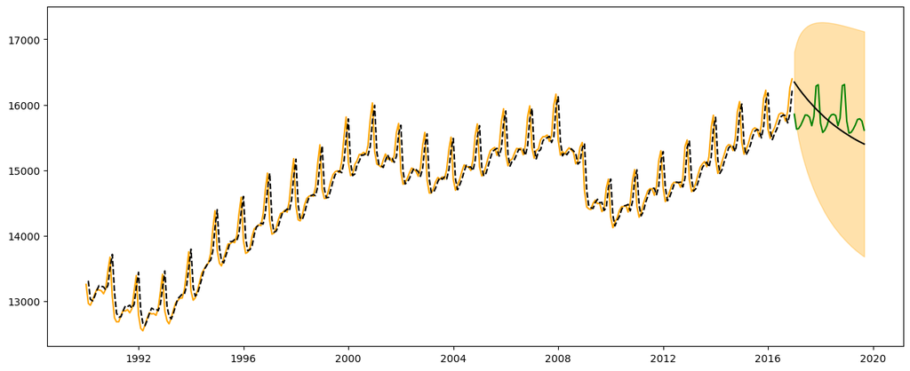

```python
fig, ax = plt.subplots( figsize=(15, 6) )

ax.plot( train_series, color='orange', label='train' )

ax.plot( test_series, color = 'green', label ='test' )

ax.plot( train_ar_01_model_fit.fittedvalues, color='black', linestyle='--', label='fits' )

ax.fill_between(ar_01_forecast_object.conf_int().index,
                ar_01_forecast_object.conf_int().lower,
                ar_01_forecast_object.conf_int().upper,
                color='orange', alpha=0.33)

ax.plot( ar_01_forecast_object.predicted_mean, color='black', label='forecast' )

plt.show()
```

Extracting and organizing the forecast with the Prediction Interval is rather tedious. Therefore, let's define a function to help streamline the predictions. This function is a wrapper to the `.get_prediction()` method and manages the book keeping to extracting the forecast trend and uncertainty interval.

```python
def make_ar_forecast(mod, start_step, end_step):
    forecast_object = mod.get_prediction( start_step, end_step )

    forecast_df = forecast_object.conf_int()

    forecast_df['trend'] = forecast_object.predicted_mean

    return forecast_df
```

The forecasts on the test set fro the AR-1 model are made below.

```python
ar_1_forecasts = make_ar_forecast( train_ar_01_model_fit, test_series.index[0], test_series.index[-1] )
```

We now have the forecasted trend and prediction interval lower and upper bounds in a convenient DataFrame.

```python
ar_1_forecasts.head()
```

|  | lower | upper | trend |
| --- | --- | --- | --- |
| 2017-01-01 | 15880.539858 | 16809.916839 | 16345.228348 |
| 2017-02-01 | 15651.397218 | 16944.164819 | 16297.781019 |
| 2017-03-01 | 15473.094134 | 17030.714354 | 16251.904244 |
| 2017-04-01 | 15322.678462 | 17092.413613 | 16207.546037 |
| 2017-05-01 | 15191.029745 | 17138.282521 | 16164.656133 |

The forecasts are visualized using the figure style from lecture in the cell below.

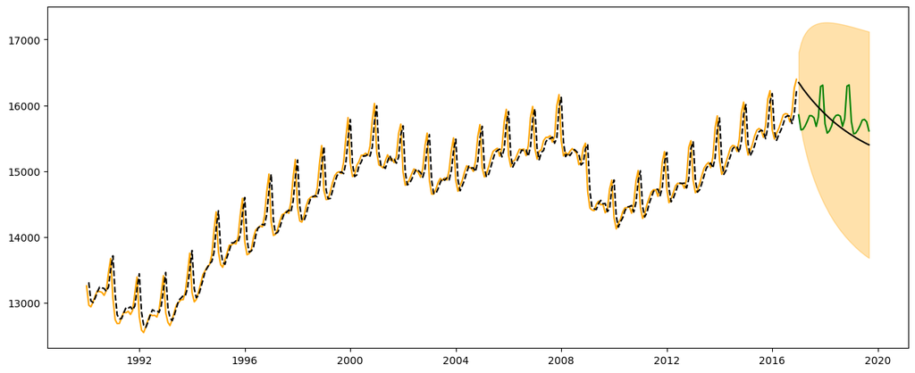

```python
fig, ax = plt.subplots( figsize=(15, 6) )

ax.plot( train_series, color='orange', label='train' )

ax.plot( test_series, color = 'green', label ='test' )

ax.plot( train_ar_01_model_fit.fittedvalues, color='black', linestyle='--', label='fits' )

ax.fill_between( ar_1_forecasts.index,
                 ar_1_forecasts.lower,
                 ar_1_forecasts.upper,
                color='orange', alpha = 0.33)

ax.plot( ar_1_forecasts.trend, color='black', label='forecast' )

plt.show()
```

Let's use the same function to organize the forecast and Prediction Interval for the 2-lag AR model.

```python
ar_2_forecasts = make_ar_forecast( train_ar_02_model_fit, test_series.index[0], test_series.index[-1] )
```

The forecasts and Prediction Intervals for the 2-lag AR model are **not** that different from the 1-lag AR model!

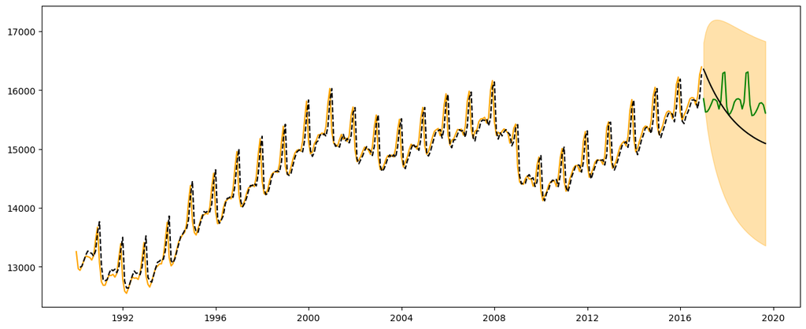

```python
fig, ax = plt.subplots( figsize=(15, 6) )

ax.plot( train_series, color='orange', label='train' )

ax.plot( test_series, color = 'green', label ='test' )

ax.plot( train_ar_02_model_fit.fittedvalues, color='black', linestyle='--', label='fits' )

ax.fill_between( ar_2_forecasts.index,
                 ar_2_forecasts.lower,
                 ar_2_forecasts.upper,
                color='orange', alpha = 0.33)

ax.plot( ar_2_forecasts.trend, color='black', label='forecast' )

plt.show()
```

### More lags

Let's increase the complexity further by adding more lags in the model. We will not manually create the features and fit the linear model. We will use `AutoReg()` to fit the 3-lag AR model directly. This saves time since `AutoReg()` creates all of the features for us. The 3-lag AR model is more commonly referred to as the AR-3 model.

```python
train_ar_03_model_fit = AutoReg( train_series, 3, old_names=False).fit()
```

```python
print( train_ar_03_model_fit.summary() )
```

```
                            AutoReg Model Results
==============================================================================
Dep. Variable:               Employed   No. Observations:                  324
Model:                     AutoReg(3)   Log Likelihood               -2170.232
Method:               Conditional MLE   S.D. of innovations            208.911
Date:                Tue, 14 Mar 2023   AIC                           4350.465
Time:                        22:13:32   BIC                           4369.322
Sample:                    04-01-1990   HQIC                          4357.994
                         - 12-01-2016
===============================================================================
                  coef    std err          z      P>|z|      [0.025      0.975]
-------------------------------------------------------------------------------
const         362.7355    195.931      1.851      0.064     -21.282     746.753
Employed.L1     1.2413      0.050     24.719      0.000       1.143       1.340
Employed.L2    -0.7030      0.076     -9.243      0.000      -0.852      -0.554
Employed.L3     0.4377      0.050      8.711      0.000       0.339       0.536
                                    Roots
=============================================================================
                  Real          Imaginary           Modulus         Frequency
-----------------------------------------------------------------------------
AR.1            1.0207           -0.0000j            1.0207           -0.0000
AR.2            0.2927           -1.4672j            1.4961           -0.2187
AR.3            0.2927           +1.4672j            1.4961            0.2187
-----------------------------------------------------------------------------
```

The forecasts for the AR-3 model are made and visualized below.

```python
ar_03_forecasts = make_ar_forecast( train_ar_03_model_fit, test_series.index[0], test_series.index[-1] )
```

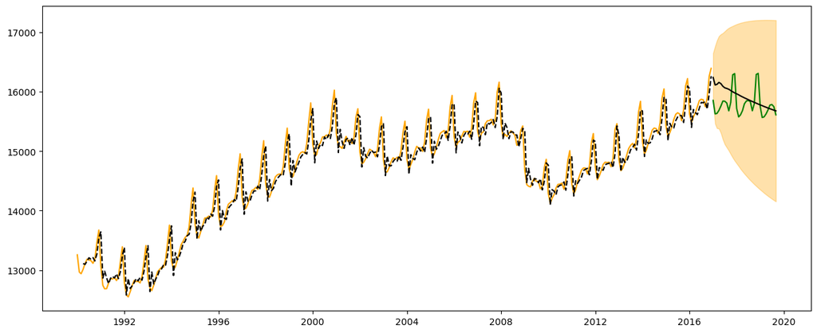

```python
fig, ax = plt.subplots( figsize=(15, 6) )

ax.plot( train_series, color='orange', label='train' )

ax.plot( test_series, color = 'green', label ='test' )

ax.plot( train_ar_03_model_fit.fittedvalues, color='black', linestyle='--', label='fits' )

ax.fill_between( ar_03_forecasts.index,
                 ar_03_forecasts.lower,
                 ar_03_forecasts.upper,
                color='orange', alpha = 0.33)

ax.plot( ar_03_forecasts.trend, color='black', label='forecast' )

plt.show()
```

Look closely at the forecasted trend in the figure above. You will notice that there are several "wiggles" present in the first few months which were **not** present in the forecasts from the AR-1 model. Let's make that explicit by directly comparing the forecasts from the 2 models. The concatenated DataFrames are demonstrated below. The `pd.concat()` function is used with the `keys` argument provided to specify which model the forecasts come from.

```python
pd.concat([ar_1_forecasts, ar_03_forecasts], axis=0, keys=['AR-1', 'AR-3']).reset_index(names=['model', 'date_dt'])
```

|  | model | date_dt | lower | upper | trend |
| --- | --- | --- | --- | --- | --- |
| 0 | AR-1 | 2017-01-01 | 15880.539858 | 16809.916839 | 16345.228348 |
| 1 | AR-1 | 2017-02-01 | 15651.397218 | 16944.164819 | 16297.781019 |
| 2 | AR-1 | 2017-03-01 | 15473.094134 | 17030.714354 | 16251.904244 |
| 3 | AR-1 | 2017-04-01 | 15322.678462 | 17092.413613 | 16207.546037 |
| 4 | AR-1 | 2017-05-01 | 15191.029745 | 17138.282521 | 16164.656133 |
| ... | ... | ... | ... | ... | ... |
| 61 | AR-3 | 2019-05-01 | 14246.358561 | 17208.373557 | 15727.366059 |
| 62 | AR-3 | 2019-06-01 | 14221.936303 | 17207.913496 | 15714.924900 |
| 63 | AR-3 | 2019-07-01 | 14198.337660 | 17207.136301 | 15702.736981 |
| 64 | AR-3 | 2019-08-01 | 14175.523594 | 17206.067085 | 15690.795340 |
| 65 | AR-3 | 2019-09-01 | 14153.459285 | 17204.730322 | 15679.094804 |

66 rows × 5 columns

The `.reset_index()` method is used to remove the hierarchical index. The forecasts from the two models are compared using a line chart from Seaborn below. As you can see the AR-3 forecasts have extra "wiggles" not present in the forecasts from the simpler AR-1 model. This is because AR-3 looks further back in time and thus "understands" more seasonal patterns compared to the 1-lag model.

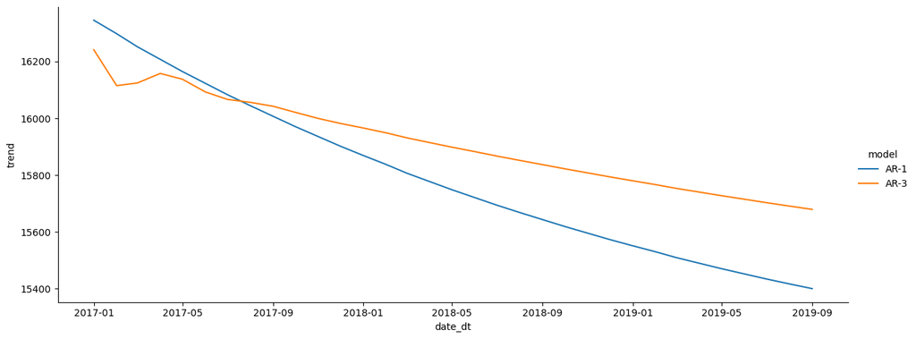

```python
sns.relplot(data = pd.concat([ar_1_forecasts, ar_03_forecasts], axis=0, keys=['AR-1', 'AR-3']).reset_index(names=['model', 'date_dt']),
            x='date_dt',
            y='trend',
            hue='model',
            kind='line', aspect=2.5)

plt.show()
```

Let's keep going. Let's try an AR model with 6 lags. The AR-6 model is fit and forecasts are made and visualized below.

```python
train_ar_06_model_fit = AutoReg( train_series, 6, old_names=False).fit()
```

```python
ar_06_forecasts = make_ar_forecast( train_ar_06_model_fit, test_series.index[0], test_series.index[-1] )
```

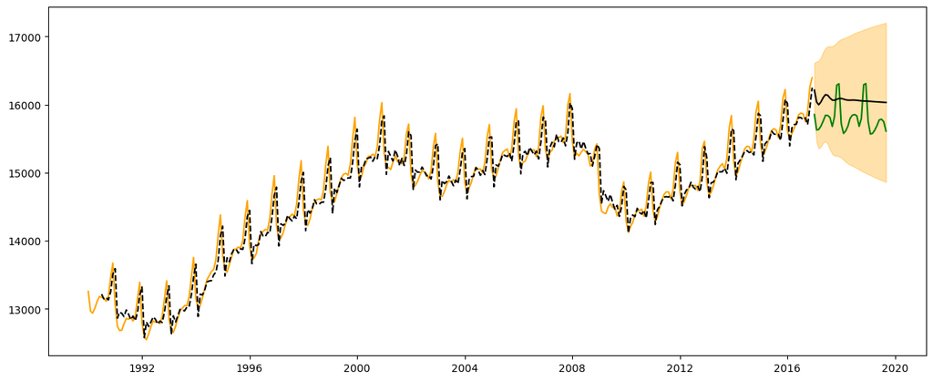

```python
fig, ax = plt.subplots( figsize=(15, 6) )

ax.plot( train_series, color='orange', label='train' )

ax.plot( test_series, color = 'green', label ='test' )

ax.plot( train_ar_06_model_fit.fittedvalues, color='black', linestyle='--', label='fits' )

ax.fill_between( ar_06_forecasts.index,
                 ar_06_forecasts.lower,
                 ar_06_forecasts.upper,
                color='orange', alpha = 0.33)

ax.plot( ar_06_forecasts.trend, color='black', label='forecast' )

plt.show()
```

"Looking" back half a year (6 months) changes the forecasted trends even more! The trend does not decrease as much into the future as we had seen with the AR-1 and AR-3 models. The figure below makes that comparison explicit by comparing the AR-1, AR-3, and AR-6 forecasted trends.

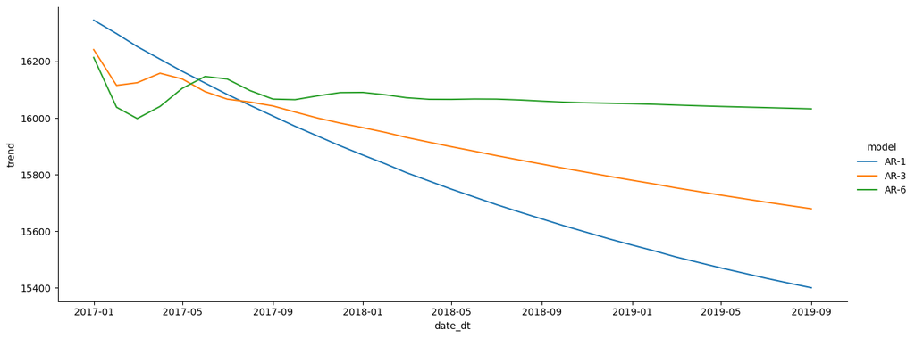

```python
sns.relplot(data = pd.concat([ar_1_forecasts, ar_03_forecasts, ar_06_forecasts], axis=0, keys=['AR-1', 'AR-3', 'AR-6']).reset_index(names=['model', 'date_dt']),
            x='date_dt',
            y='trend',
            hue='model',
            kind='line', aspect=2.5)

plt.show()
```

What if we include 1 year worth of lags and thus "look" back 12 Seasons (months)?

```python
train_ar_12_model_fit = AutoReg( train_series, 12, old_names=False).fit()
```

```python
ar_12_forecasts = make_ar_forecast( train_ar_12_model_fit, test_series.index[0], test_series.index[-1] )
```

The forecast visualization shown below reveals a Seasonal pattern propagating into the future! The predicted trend is not a straight line! There is a repeated pattern that occurs through time! The pattern could only be identified because the model explicitly includes 12 previous months as features in the model!

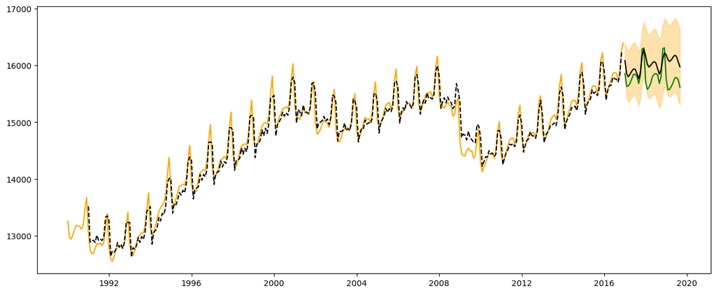

```python
fig, ax = plt.subplots( figsize=(15, 6) )

ax.plot( train_series, color='orange', label='train' )

ax.plot( test_series, color = 'green', label ='test' )

ax.plot( train_ar_12_model_fit.fittedvalues, color='black', linestyle='--', label='fits' )

ax.fill_between( ar_12_forecasts.index,
                 ar_12_forecasts.lower,
                 ar_12_forecasts.upper,
                color='orange', alpha = 0.33)

ax.plot( ar_12_forecasts.trend, color='black', label='forecast' )

plt.show()
```

We can keep going...let's try 24 lags or 2 years worth of data...

```python
train_ar_24_model_fit = AutoReg( train_series, 24, old_names=False).fit()
```

```python
ar_24_forecasts = make_ar_forecast( train_ar_24_model_fit, test_series.index[0], test_series.index[-1] )
```

The visualization reveals the forecasted trend looks very close to the observed hold-out test set values!

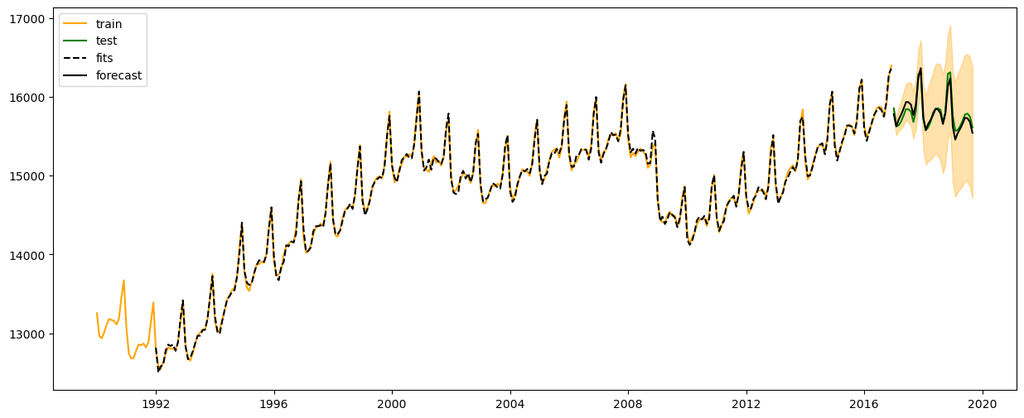

```python
fig, ax = plt.subplots( figsize=(15, 6) )

ax.plot( train_series, color='orange', label='train' )

ax.plot( test_series, color = 'green', label ='test' )

ax.plot( train_ar_24_model_fit.fittedvalues, color='black', linestyle='--', label='fits' )

ax.fill_between( ar_24_forecasts.index,
                 ar_24_forecasts.lower,
                 ar_24_forecasts.upper,
                color='orange', alpha = 0.33)

ax.plot( ar_24_forecasts.trend, color='black', label='forecast' )

ax.legend(loc='upper left')

plt.show()
```

But...what if we try more than 24 lags? What if we consider 48 Seasons (months) or 4 years worth of lags?!?

```python
train_ar_48_model_fit = AutoReg( train_series, 48, old_names=False).fit()
```

```python
ar_48_forecasts = make_ar_forecast( train_ar_48_model_fit, test_series.index[0], test_series.index[-1] )
```

The AR-48 model forecasts visualized below demonstrate that the forecast performance on the hold-out test set is worse than what we saw with the AR-24 model! The forecasts are deviating from the observed hold-out values!

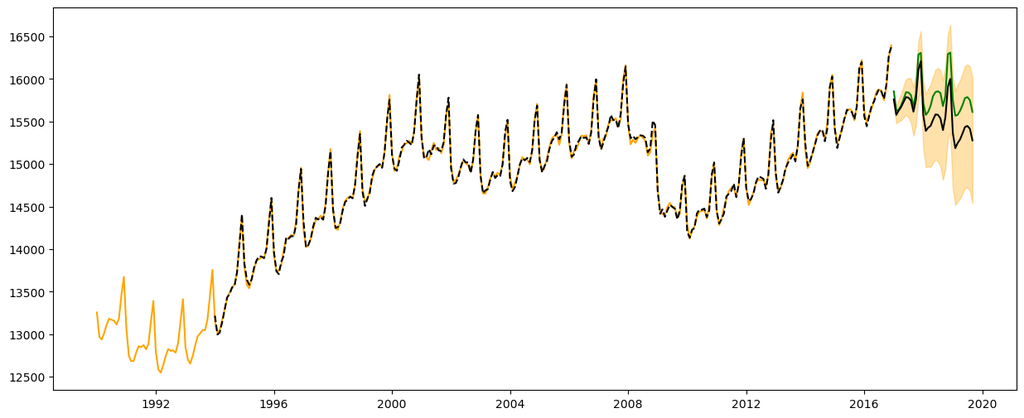

```python
fig, ax = plt.subplots( figsize=(15, 6) )

ax.plot( train_series, color='orange', label='train' )

ax.plot( test_series, color = 'green', label ='test' )

ax.plot( train_ar_48_model_fit.fittedvalues, color='black', linestyle='--', label='fits' )

ax.fill_between( ar_48_forecasts.index,
                 ar_48_forecasts.lower,
                 ar_48_forecasts.upper,
                color='orange', alpha = 0.33)

ax.plot( ar_48_forecasts.trend, color='black', label='forecast' )

plt.show()
```

## Model Selection

We can try as few or or as many lags as we want, as long as there are more observations than features in the model. Thus, the natural question becomes what is the **best** number of lags??!

We need a performance metric to help us identify the "best" model, just as we discussed with "regular" regression and classification problems! Even though we created the hold-out test set, we will only consider the training set performance for now. As we discussed with "regular" regression and classification we **must** use performance metrics that **penalize** training set performance based on the number of features. Thus, we should **not** consider the training set RMSE to select the best number of lags. Instead, we should consider AIC or BIC to identify the best number of lags!

All `AutoReg()` models include `.aic` and `.bic` attributes. We could iterate over many values for the lags and extract the performance metrics. However, there are some slight nuances to properly executing this procedure for AR models. AIC and BIC are calculated by **summing** the log-likelihood. Thus, their values will depend on the number of observations. As discussed in lecture and demonstrated in this notebook, larger lag values will "drop out" more observations from the beginning of the time series. Larger lag values will use fewer training points than smaller lag values, thus creating an "apples-to-oranges" performance metric comparison.

To overcome this issue, the `ar_select_order()` function calculates AIC and BIC **over the same measurements** in **all** models. Thus, we do not have to worry about higher lag AR models having fewer measurements than smaller lag AR models. The `ar_select_order()` function ensures a fair performance metric comparison.

The `ar_select_order()` function is imported below.

```python
from statsmodels.tsa.ar_model import ar_select_order
```

The optimal number of lags is identified based on AIC in the cell below. We will try up to a maximum of 48 lags.

```python
ar_tune_lags = ar_select_order( train_series, maxlag=48, period=12, ic='aic', old_names=False )
```

The result is a specialized data type.

```python
type( ar_tune_lags )
```

```
statsmodels.tsa.ar_model.AROrderSelectionResults
```

The `.ar_lags` attribute are the required lags that yield the best performance according to AIC. As shown below, the best model requires 26 lags! This is consistent with what we saw in our visualizations. This is consistent with what we saw in our previous visualizations. Using 48 lags produced **worse** future performance compared to using 24 lags! The `ar_select_order()` function tried even more possible lags than we considered. Behind the scenes all models from AR-1 to AR-48 were fit and evaluated. AIC (and BIC) are penalizing training set performance in the hope that model performs better on new data.

```python
ar_tune_lags.ar_lags
```

```
[1,
 2,
 3,
 4,
 5,
 6,
 7,
 8,
 9,
 10,
 11,
 12,
 13,
 14,
 15,
 16,
 17,
 18,
 19,
 20,
 21,
 22,
 23,
 24,
 25,
 26]
```

The tuned or optimal AR model is fit by calling the `.model.fit()` method.

```python
ar_tune_model_fit = ar_tune_lags.model.fit()
```

The summary for the tuned AR model reveals the coefficients associated with each of the 26 lags.

```python
print( ar_tune_model_fit.summary() )
```

```
                            AutoReg Model Results
==============================================================================
Dep. Variable:               Employed   No. Observations:                  324
Model:                    AutoReg(26)   Log Likelihood               -1485.449
Method:               Conditional MLE   S.D. of innovations             35.367
Date:                Tue, 14 Mar 2023   AIC                           3026.898
Time:                        22:51:13   BIC                           3130.417
Sample:                    03-01-1992   HQIC                          3068.336
                         - 12-01-2016
================================================================================
                   coef    std err          z      P>|z|      [0.025      0.975]
--------------------------------------------------------------------------------
const           91.1071     42.308      2.153      0.031       8.184     174.030
Employed.L1      1.1268      0.057     19.812      0.000       1.015       1.238
Employed.L2     -0.0488      0.081     -0.605      0.545      -0.207       0.109
Employed.L3      0.0823      0.078      1.050      0.294      -0.071       0.236
Employed.L4     -0.0783      0.078     -1.000      0.317      -0.232       0.075
Employed.L5     -0.1716      0.078     -2.190      0.029      -0.325      -0.018
Employed.L6      0.1201      0.079      1.525      0.127      -0.034       0.275
Employed.L7     -0.0596      0.078     -0.760      0.447      -0.213       0.094
Employed.L8      0.1806      0.079      2.298      0.022       0.027       0.335
Employed.L9     -0.1011      0.079     -1.282      0.200      -0.256       0.054
Employed.L10    -0.0518      0.079     -0.659      0.510      -0.206       0.102
Employed.L11    -0.0640      0.078     -0.818      0.413      -0.217       0.089
Employed.L12     0.6405      0.078      8.194      0.000       0.487       0.794
Employed.L13    -0.5979      0.086     -6.922      0.000      -0.767      -0.429
Employed.L14    -0.0969      0.086     -1.122      0.262      -0.266       0.072
Employed.L15    -0.0726      0.078     -0.927      0.354      -0.226       0.081
Employed.L16     0.0779      0.078      0.994      0.320      -0.076       0.231
Employed.L17     0.1710      0.078      2.182      0.029       0.017       0.325
Employed.L18    -0.1197      0.079     -1.520      0.128      -0.274       0.035
Employed.L19     0.0566      0.078      0.722      0.470      -0.097       0.210
Employed.L20    -0.1754      0.079     -2.233      0.026      -0.329      -0.021
Employed.L21     0.0883      0.079      1.121      0.262      -0.066       0.243
Employed.L22     0.0513      0.078      0.654      0.513      -0.102       0.205
Employed.L23     0.0798      0.078      1.021      0.307      -0.073       0.233
Employed.L24     0.3328      0.078      4.260      0.000       0.180       0.486
Employed.L25    -0.5160      0.081     -6.397      0.000      -0.674      -0.358
Employed.L26     0.1397      0.056      2.485      0.013       0.030       0.250
                                    Roots
```

[output cut: 15 more lines]

```
AR.13           -0.0012           +0.9996j            0.9996            0.2502
AR.14            0.2075           -1.0638j            1.0839           -0.2193
AR.15            0.2075           +1.0638j            1.0839            0.2193
AR.16            0.4995           -0.8662j            0.9999           -0.1667
AR.17            0.4995           +0.8662j            0.9999            0.1667
AR.18            0.7763           -0.7457j            1.0764           -0.1218
AR.19            0.7763           +0.7457j            1.0764            0.1218
AR.20            0.8673           -0.5012j            1.0017           -0.0834
AR.21            0.8673           +0.5012j            1.0017            0.0834
AR.22            1.0771           -0.1625j            1.0893           -0.0238
AR.23            1.0771           +0.1625j            1.0893            0.0238
AR.24            1.0355           -0.0000j            1.0355           -0.0000
AR.25            1.0393           -0.0000j            1.0393           -0.0000
AR.26            2.7164           -0.0000j            2.7164           -0.0000
------------------------------------------------------------------------------
```

The diagnostic plot reveals the residuals are uncorrelated for the optimal model.

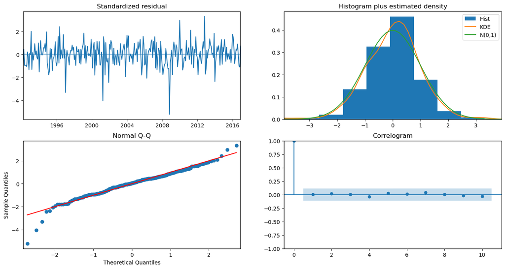

```python
ar_tune_model_fit.plot_diagnostics(figsize=(16,8))

plt.show()
```

Lastly, the forecasts associated with the tuned AR model are visualized below.

```python
ar_tune_forecasts = make_ar_forecast( ar_tune_model_fit, test_series.index[0], test_series.index[-1] )
```

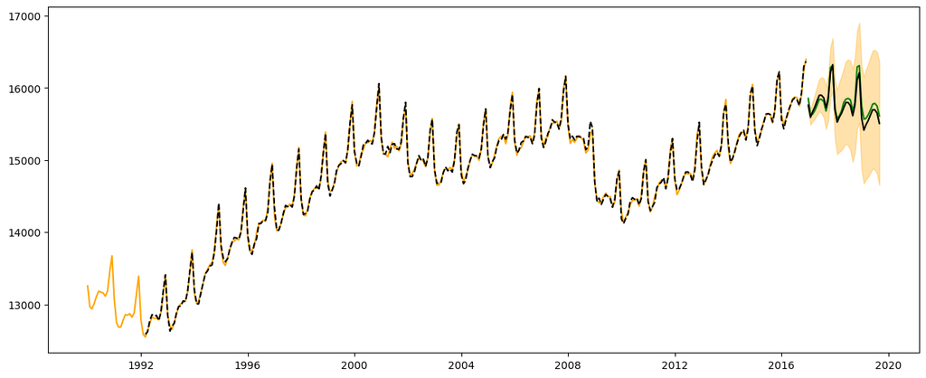

```python
fig, ax = plt.subplots( figsize=(15, 6) )

ax.plot( train_series, color='orange', label='train' )

ax.plot( test_series, color = 'green', label ='test' )

ax.plot( ar_tune_model_fit.fittedvalues, color='black', linestyle='--', label='fits' )

ax.fill_between( ar_tune_forecasts.index,
                 ar_tune_forecasts.lower,
                 ar_tune_forecasts.upper,
                color='orange', alpha = 0.33)

ax.plot( ar_tune_forecasts.trend, color='black', label='forecast' )

plt.show()
```

The forecasted trends for all fitted AR models in this notebook are visualized below. This shows how the model needed more lags in order to capture the repeating seasonal pattern present in the data.

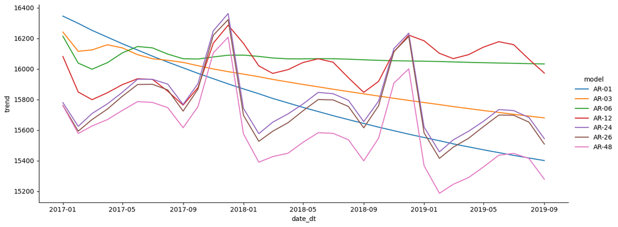

```python
sns.relplot(data = pd.concat([ar_1_forecasts, ar_03_forecasts, ar_06_forecasts, ar_12_forecasts, ar_24_forecasts, ar_tune_forecasts, ar_48_forecasts], axis=0, keys=['AR-01', 'AR-03', 'AR-06', 'AR-12', 'AR-24', 'AR-26', 'AR-48']).reset_index(names=['model', 'date_dt']),
            x='date_dt',
            y='trend',
            hue='model',
            kind='line', aspect=2.5)

plt.show()
```

## Summary

This notebook demonstrated how AR models are nothing more than Linear Models! Specialized AR modeling functions streamline fitting and making predictions from such models because we do not need to manually create the lagged features!